# 3.GC biased gene sets

To check whether any gene ontology or other functional categories were associated with high or low GC content, lists of genes were generated biased by GC content.

Preliminary work looking at GC biases using intervals over the whole range of GC content in the genome only identified categories using genes with high or low GC content, not the intermediate ranges, so we’re focusing on the ends of the distribution.

## GC distribution for all the genes in Mus_musculus.GRCm38.94

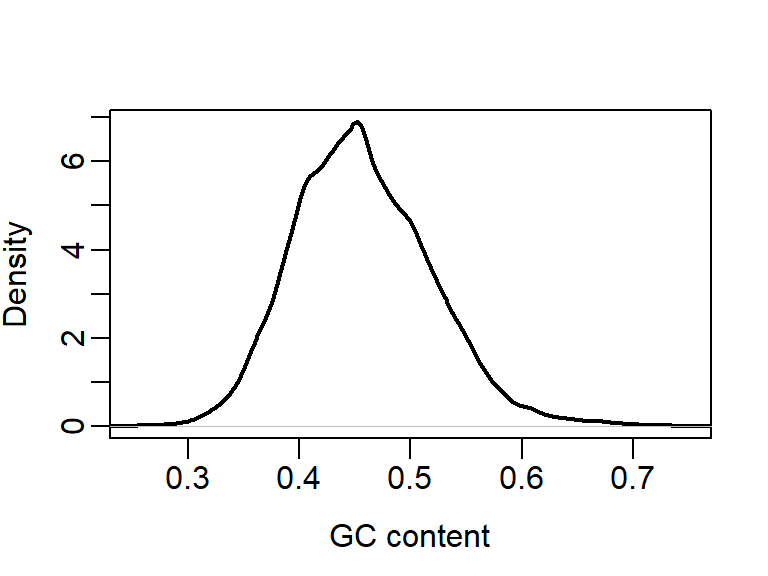

## Selecting GC thresholds

For the preliminary work, arbitrary thresholds of 0.35, 0.4, 0.5, 0.55, 0.6 GC were used.

However, selecting thresholds dependent on the distribution of the data is a more robust method for applying to different species and future versions of this genome. The GC content thresholds will be based on the distribution of GC content over all genes. The probabilities selected will be 0.01, 0.05, 0.1, 0.9, 0.95, 0.99.

[output not shown]

[figure not shown]

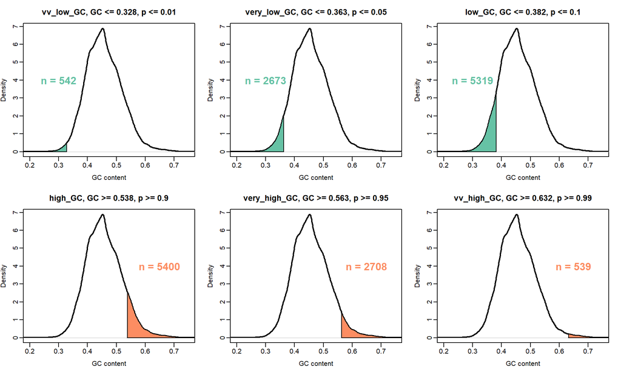

## Generating the biased gene lists

The thresholds are used to filter the set of genes. 200 genes are then randomly selected from the filtered set. This is repeated 100 times to get 100 lists each containing 200 genes.

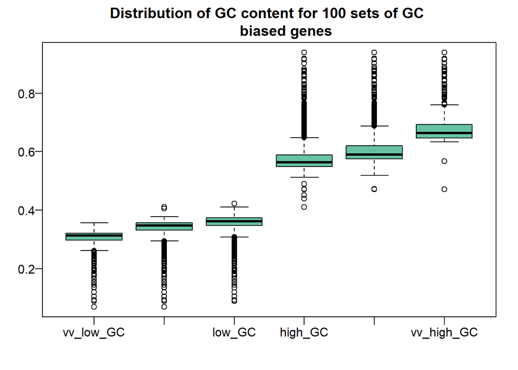

## GO overrepresentation analysis

The 100 sets of 200 genes for each GC category were run through a GO overrepresentation analysis.

The number of gene sets (out of 100) that returned significant results from the GO overrepresentation analysis.

| category | results |
| --- | --- |
| vv_low_GC | 100 |
| very_low_GC | 100 |
| low_GC | 100 |
| high_GC | 11 |
| very_high_GC | 14 |
| vv_high_GC | 5 |

The bean plots show the number of categories returned from each gene list. The null results have been removed.

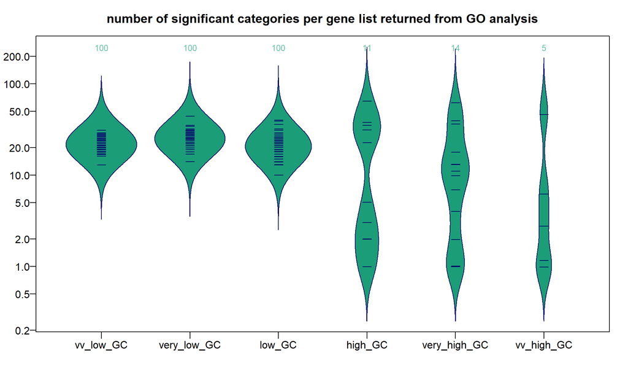

All 100 sets of genes in the low GC categories returned significant results, but only 11, 14 and 5 sets returned significant results for the 3 high GC categories. We can plot out the distribution of the number of categories that were identified for each of the sets. Each horizontal line in the bean is the number of results identified for a gene list.

We can now see whether any functional categories appeared multiple times during the 100 tests. They would only appear once per test, so the maximum number of appearances should be 100.

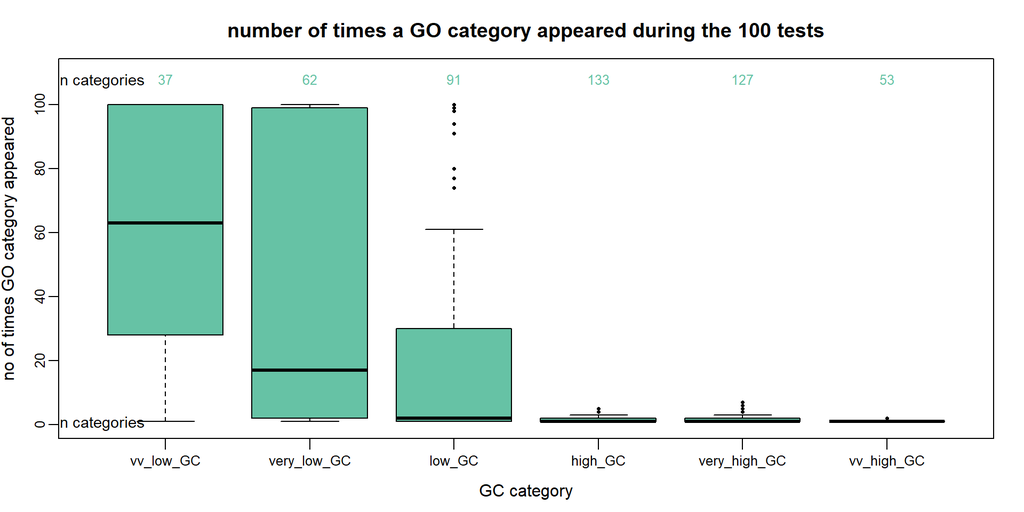

Replot just showing the data for categories that appeared >= 30 times

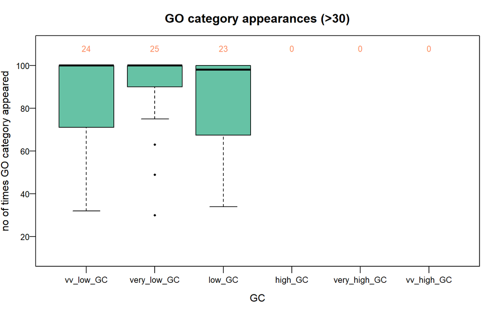

Create a dataset that contains these suspect set of categories

```
   vv_low_GC  very_low_GC       low_GC      high_GC very_high_GC
          24           25           23            0            0
  vv_high_GC
           0
```

We don’t need empty files so remove GC categories with no results.

```
  vv_low_GC very_low_GC      low_GC
         24          25          23
```

Deduplicate

```
[1] 23
[1] 23
[1] 23
```

```
[1] 23
```

There are 23 overlapping categories between vv low_GC and very_low_GC. There are 23 overlapping categories between vv low_GC and low_GC. There are 23 overlapping categories between very low_GC and low_GC.

The duplicate terms will be removed from the more stringent categories.

```
  vv_low_GC very_low_GC      low_GC
          1           2          23
```

Didn’t get any significant categories using GC > 0.55 or 0.6, though I did before - it may be that the filters such as the max number of genes is too strict?

`for i in {1..100}; do ../filter_gene_info.pl --max_GC 0.6 ../Mus_musculus.GRCm38.94_gene_info.txt` `--number_of_genes 200 --output_file highGC_0.6_${i}; done`

Extract the gene names and remove header `for i in highGC*; do cut -f2 $i | tail -n 200 > ${i}_just_genes.txt; done`

Laura Biggins

2019-10-24